# Challenges AND Supervision Analyses

Luis P. Prieto

2021-09-09

## Descriptive graphs

### Overall (low-difficult, high-easy)

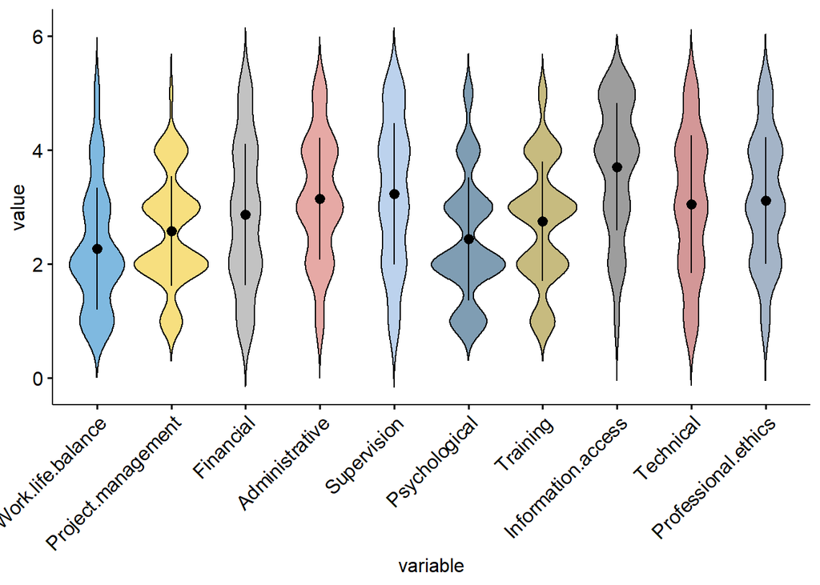

### Per type of respondent

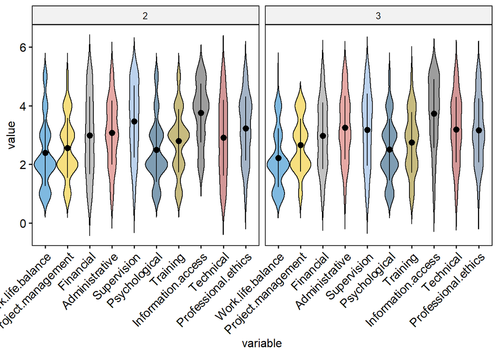

… where Type=2 (PhD students), Type=3 (PhD holders)

## Correlations between challenges

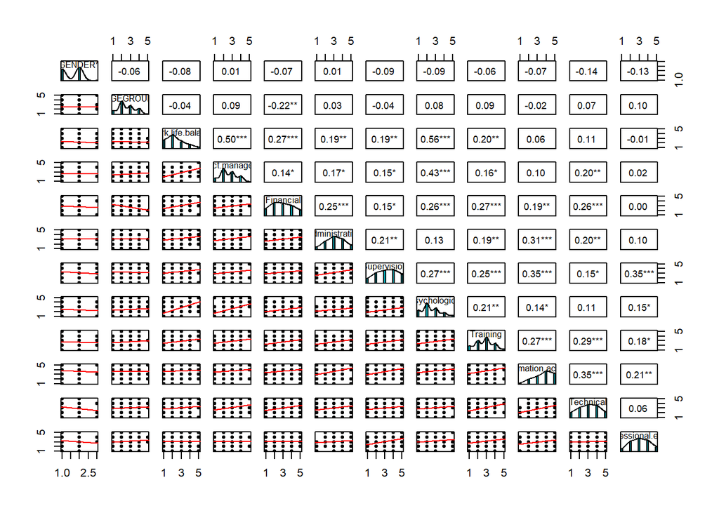

There’s quite a few of these challenges correlated with each other. One of the strongest is Work.life.balance <–> Project.management <–> Psychological.

To a lesser degree, Supervision <–> Information.access <–> Professional.ethics … or Technical <–> Training <–> Information.access.

Regarding demographics, there seems to be some correlation between AGEGROUP and Financial challenges (older respondents found Financial challenges more difficult).

These correlations will play a role in the clusters defined below…

### Alternative: PARTIAL correlations graph between challenges (and demographics?)

Just the challenges…

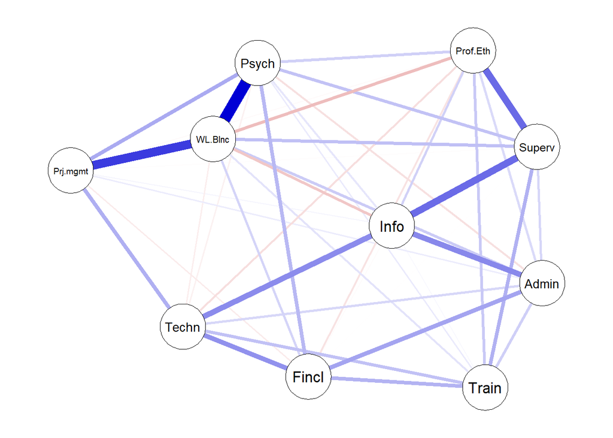

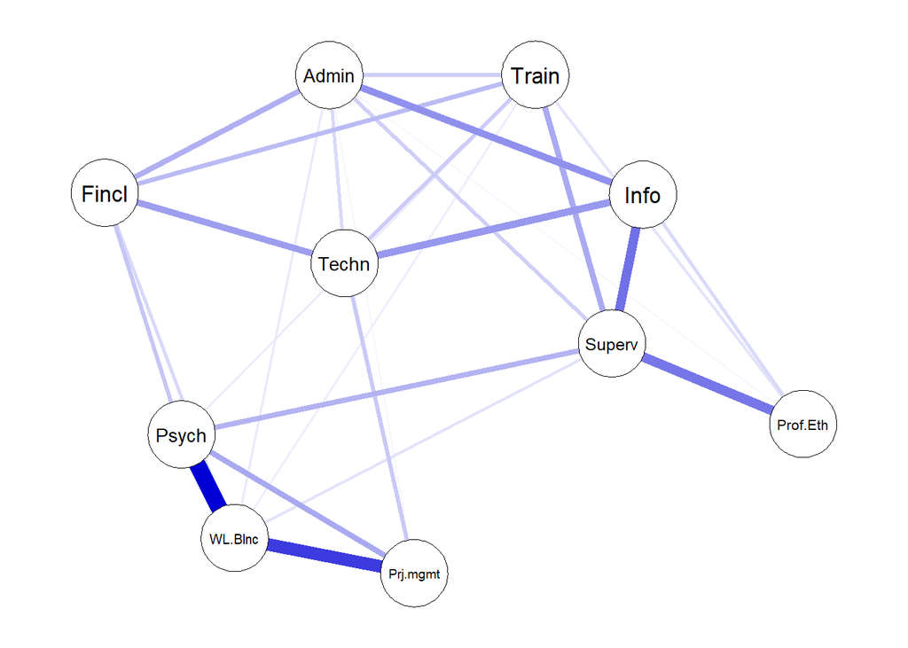

… and with some demographics

```
## $estimate
##                GENDER         AGE     WL.Blnc    Prj.mgmt        Fincl
## GENDER    1.000000000 -0.07989511 -0.15541221  0.13392033 -0.003015755
## AGE      -0.079895113  1.00000000 -0.10675018  0.10909526 -0.192613319
## WL.Blnc  -0.155412211 -0.10675018  1.00000000  0.33679818  0.084053655
## Prj.mgmt  0.133920326  0.10909526  0.33679818  1.00000000 -0.031291923
## Fincl    -0.003015755 -0.19261332  0.08405366 -0.03129192  1.000000000
## Admin     0.075613335  0.07996232  0.09203375  0.01334461  0.154584402
## Superv   -0.047417347 -0.05892359  0.09978508  0.03221606 -0.001198784
## Psych     0.021655835  0.10843277  0.36545071  0.15422740  0.139383323
## Train     0.028800973  0.08920693  0.08498227 -0.03821301  0.121065637
## Info      0.006230226 -0.07035011 -0.07348703  0.01957259 -0.011172529
## Techn    -0.156108665  0.02335418 -0.05297877  0.15041599  0.187673991
## Prof.Eth -0.111654415  0.02959029 -0.10573924  0.01673149 -0.062616984
##                Admin       Superv       Psych       Train         Info
## GENDER    0.07561333 -0.047417347  0.02165584  0.02880097  0.006230226
## AGE       0.07996232 -0.058923591  0.10843277  0.08920693 -0.070350109
## WL.Blnc   0.09203375  0.099785085  0.36545071  0.08498227 -0.073487034
## Prj.mgmt  0.01334461  0.032216062  0.15422740 -0.03821301  0.019572593
## Fincl     0.15458440 -0.001198784  0.13938332  0.12106564 -0.011172529
## Admin     1.00000000  0.062999921 -0.02802883  0.05372470  0.192179935
## Superv    0.06299992  1.000000000  0.11939270  0.12650657  0.210933749
## Psych    -0.02802883  0.119392696  1.00000000  0.01924570  0.031606250
## Train     0.05372470  0.126506567  0.01924570  1.00000000  0.029042451
## Info      0.19217994  0.210933749  0.03160625  0.02904245  1.000000000
## Techn     0.09303928  0.004056419 -0.01167508  0.08864571  0.177549017
## Prof.Eth  0.09137522  0.211428556  0.06394243  0.07210453  0.093269417
##                 Techn    Prof.Eth
## GENDER   -0.156108665 -0.11165441
## AGE       0.023354179  0.02959029
## WL.Blnc  -0.052978770 -0.10573924
## Prj.mgmt  0.150415993  0.01673149
## Fincl     0.187673991 -0.06261698
## Admin     0.093039275  0.09137522
## Superv    0.004056419  0.21142856
## Psych    -0.011675081  0.06394243
## Train     0.088645711  0.07210453
## Info      0.177549017  0.09326942
## Techn     1.000000000 -0.04187970
## Prof.Eth -0.041879701  1.00000000
```

[output cut: 63 more lines]

```
## Superv    0.00000000  2.2479315  2.3818718  3.9714709  0.07637445  3.9807871
## Psych     2.24793149  0.0000000  0.3623590  0.5950840 -0.21981899  1.2039112
## Train     2.38187179  0.3623590  0.0000000  0.5468127  1.66902574  1.3575876
## Info      3.97147086  0.5950840  0.5468127  0.0000000  3.34290151  1.7560811
## Techn     0.07637445 -0.2198190  1.6690257  3.3429015  0.00000000 -0.7885131
## Prof.Eth  3.98078712  1.2039112  1.3575876  1.7560811 -0.78851305  0.0000000
##
## $n
## [1] 171
##
## $gp
## [1] 10
##
## $method
## [1] "kendall"
```

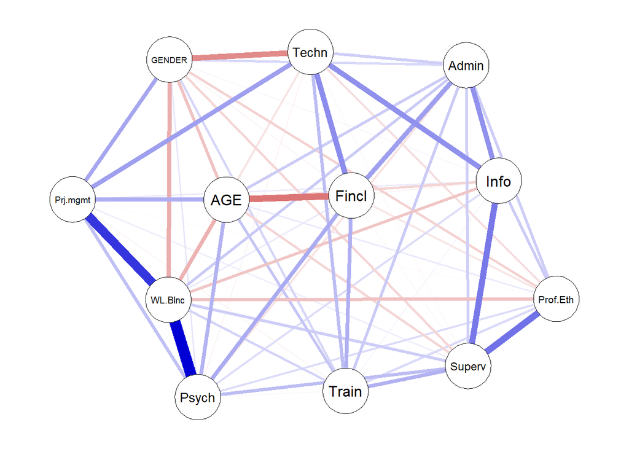

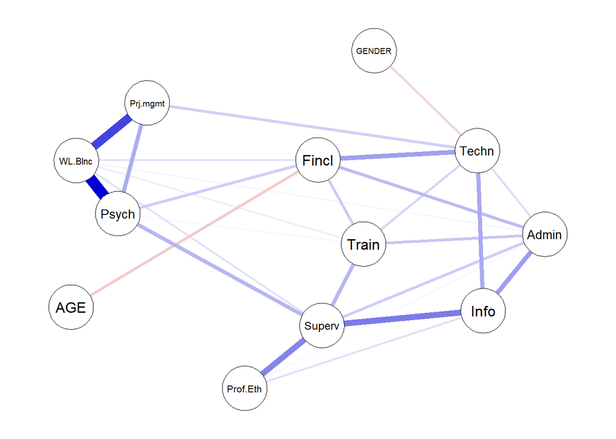

These give a similar picture to the correlations above, but might be nicer to look at? (gives an idea of clusters of challenges that appear together, like work-life balance-psych-project mgmt, or supervision-train-info-ethics-psych)

## Dimensionality reduction (PCA) of Challenges

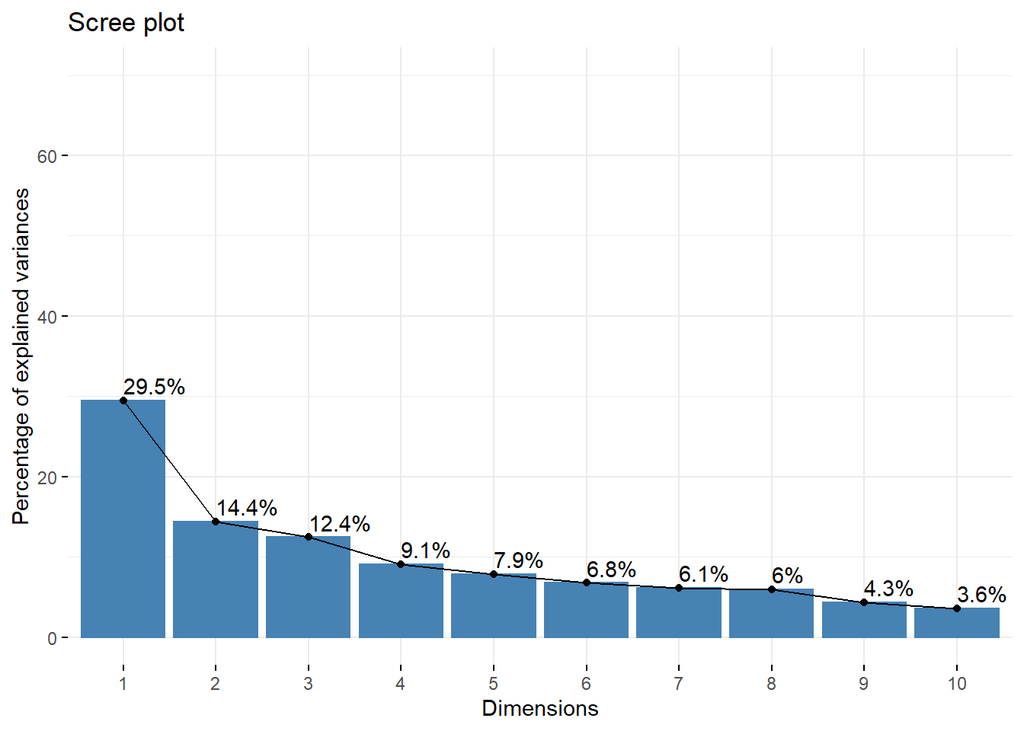

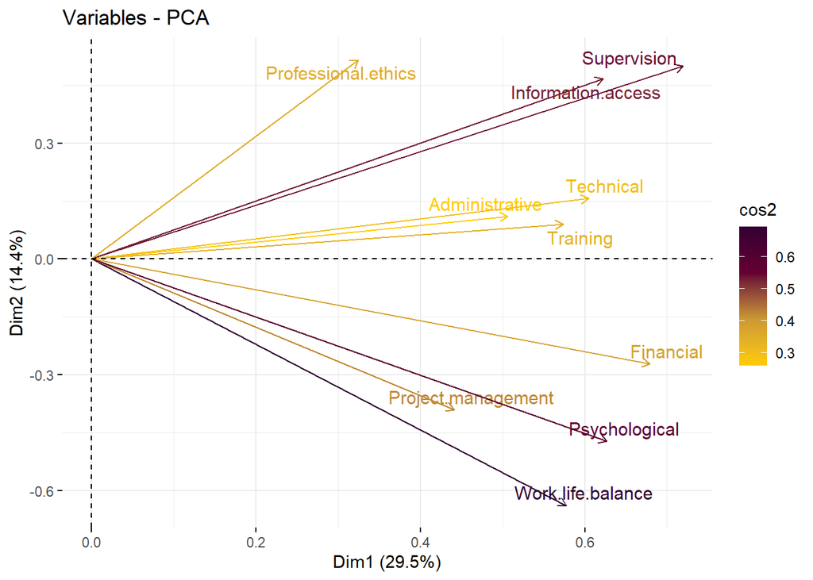

Seems like there is a big factor (find things challenging in general), then a second factor which seems to separate Psych/WLBalance/Projectmgmt/Financial vs the others?

### Alternative: Multidimensional Scaling (MDS) of challenges

See http://www.sthda.com/english/articles/31-principal-component-methods-in-r-practical-guide/122-multidimensional-scaling-essentials-algorithms-and-r-code/

PROBLEM: MDS does not seem to be reproducible! not even setting random seeds!

OPtion 1: making sense of the variables (MDS of correlations)

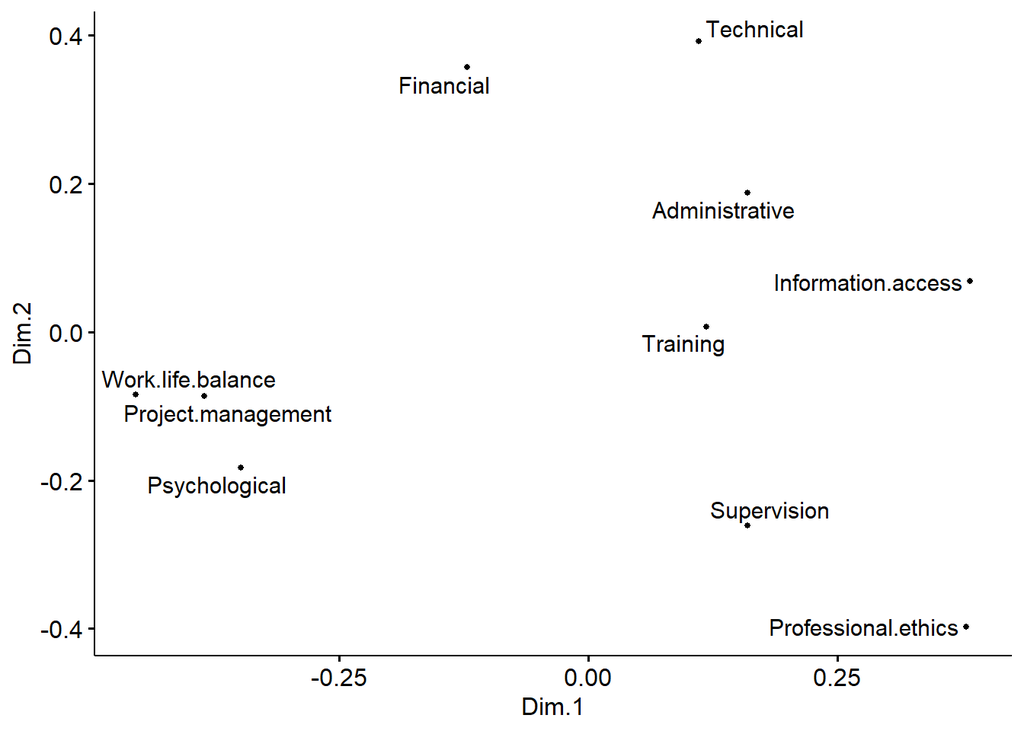

Option 2: Making sense of participants (for later clustering)

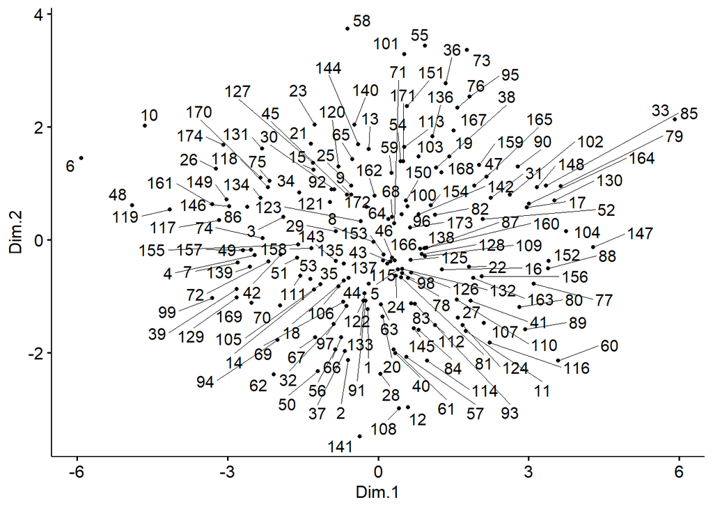

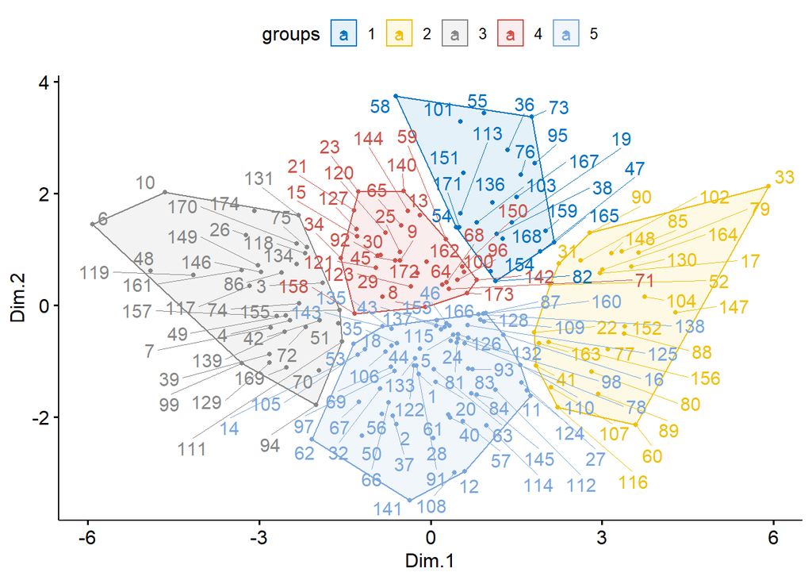

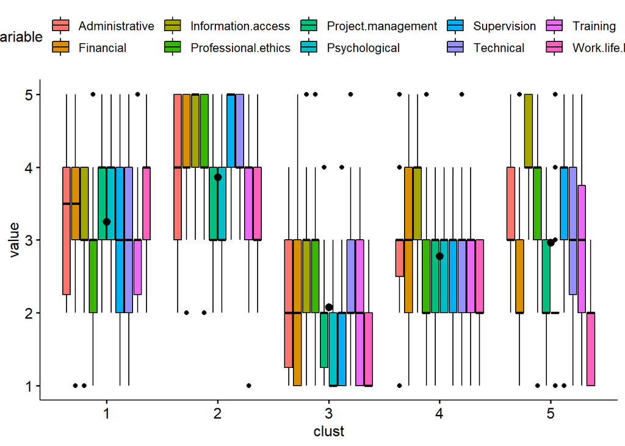

```
## # A tibble: 5 x 11
##   clust Work.life.balan~ Project.managem~ Financial Administrative Supervision
##   <fct>            <dbl>            <dbl>     <dbl>          <dbl>       <dbl>
## 1 1                 3.59             3.36      3.5            3.32        3.05
## 2 2                 3.28             3.2       4.08           3.92        4.4
## 3 3                 1.41             1.91      2.06           2.24        1.85
## 4 4                 2.32             2.81      3              3           2.74
## 5 5                 1.73             2.23      2.58           3.31        3.74
## # ... with 5 more variables: Psychological <dbl>, Training <dbl>,
## #   Information.access <dbl>, Technical <dbl>, Professional.ethics <dbl>
```

In this case, the clusters are:

1. Average challenges. Psychological, Worklife.balance are considered less challenging, professional ethics more challenging (followed by supervision)
2. Everything is relatively easy (especially supervision and info access). Project management, Worklife balance and Psychological are still the most challenging comparatively (average)
3. Everything is challenging. Psychological and worklife balance are especially challenging (followed by supervision and project management). Information access and ethics are less challenging.
4. Average challenges. Worklife.balance, training, ethics (and psychological) are more challenging. Information access is less challenging (followed by administrative and financial).
5. Average challenges, more differences across kinds of challenges: Worklife balance is most challenging, followed by Project management and Psychological. On the other hand, Info access, professional ethics and supervision are less challenging.

Are clusters related with whether a respondent had finished the PhD?

```
##
##      1  2  3  4
##   1  0 10 11  1
##   2  0 14 11  0
##   3  5 11 17  1
##   4  4 13 12  2
##   5  6 30 26  0
```

```
##
##  Pearson's Chi-squared test
##
## data:  tcl
## X-squared = 14, df = 12, p-value = 0.3
```

… and the clusters seem independent from type of respondent.

## Cluster analysis (K-means)

### k=2 clusters

This clustering is a bit useless, as it just separates people that said things are generally challenging from not so challenging. Differential trends between the two clusters are the same (regarding what is more of a challenge).

### k=5 clusters

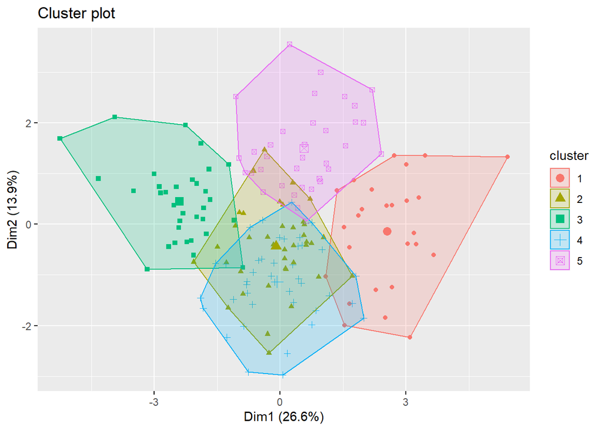

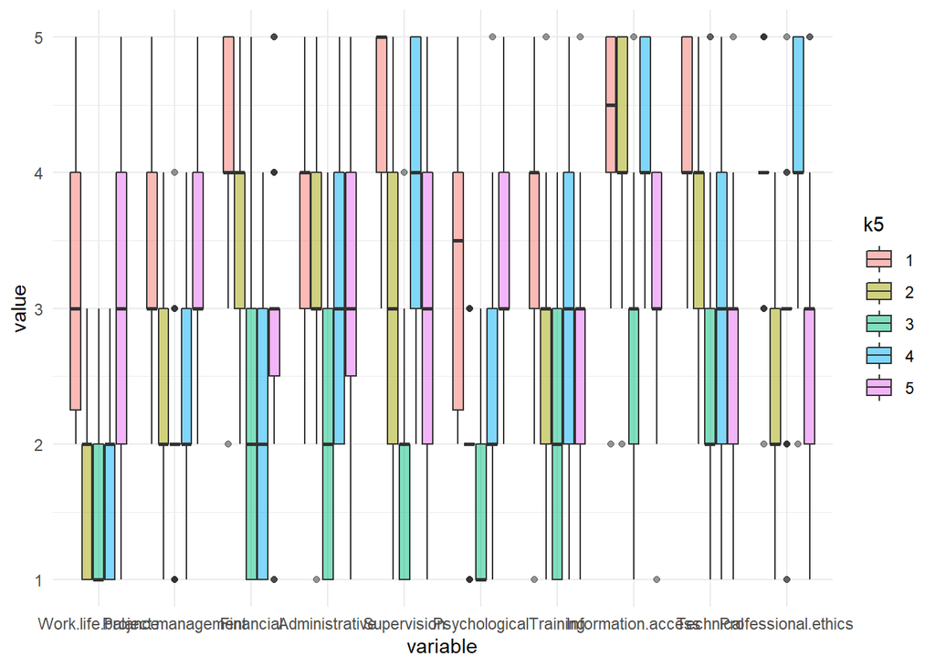

```
## [1] "Mean values per cluster"
```

| k5 | Work.life.balance | Project.management | Financial | Administrative | Supervision | Psychological | Training | Information.access | Technical | Professional.ethics |
| --- | --- | --- | --- | --- | --- | --- | --- | --- | --- | --- |
| 1 | 3.3 | 3.2 | 4.2 | 3.8 | 4.4 | 3.4 | 3.4 | 4.4 | 4.2 | 4.0 |
| 2 | 1.9 | 2.3 | 3.5 | 3.5 | 3.0 | 2.0 | 2.7 | 4.3 | 3.6 | 2.3 |
| 3 | 1.5 | 2.0 | 2.1 | 2.1 | 1.8 | 1.5 | 2.1 | 2.5 | 2.4 | 2.8 |
| 4 | 1.8 | 2.1 | 2.0 | 3.2 | 3.9 | 2.2 | 3.0 | 4.2 | 2.8 | 4.0 |
| 5 | 3.1 | 3.4 | 3.0 | 3.1 | 3.0 | 3.4 | 2.8 | 3.1 | 2.7 | 2.8 |

Initial cluster interpretation:

1. Nothing’s challenging
2. Psychological, Work-life balance challenging
3. Psychological, Work-life balance specially challenging - Supervision as well (almost everything is below average)
4. Financial, work-life balance as challenging
5. Technical, training as mildly challenging

These could be related with some of the profiles of PhD students found in De Clercq, M., Frenay, M., Azzi, A., Klein, O., & Galand, B. (2021). All You Need is Self-Determination: Investigation of PhD Students’ Motivation Profiles and Their Impact on the Doctoral Completion Process. *International Journal of Doctoral Studies, 16*, 189-209.

Are thes kmeans clusters related with whether a respondent had finished the PhD?

```
##
##      1  2  3  4
##   1  0 15 11  0
##   2  2 16 19  2
##   3  6 11 15  1
##   4  4 22 15  0
##   5  3 14 17  1
```

```
##
##  Pearson's Chi-squared test
##
## data:  tcl
## X-squared = 13, df = 12, p-value = 0.4
```

… and the clusters seem independent from type of respondent.

## Clusters vs. demographics

```
##    GENDER
## k5   1  2
##   1 15 11
##   2 17 21
##   3 12 21
##   4 21 17
##   5 13 21
```

```
##
##  Pearson's Chi-squared test
##
## data:  t
## X-squared = 5, df = 4, p-value = 0.3
```

```
##    AGEGROUP
## k5   2  3  4  5  6
##   1  3 13  8  2  0
##   2  6 17 11  4  1
##   3  5 14 10  4  0
##   4  2 18 13  8  0
##   5  6  8  8 12  1
```

```
##
##  Pearson's Chi-squared test
##
## data:  t
## X-squared = 19, df = 16, p-value = 0.3
```

```
##    PHDSTAGE
## k5   1  2  3
##   1  3  3  9
##   2  3  9  4
##   3  3  5  3
##   4  3  4 15
##   5  4  1  9
```

```
##
##  Pearson's Chi-squared test
##
## data:  t
## X-squared = 15, df = 8, p-value = 0.05
```

```
##    PHDTOPIC
## k5   1  2  3  4  5  6
##   1  6  7  8  0  1  4
##   2 10 12  5  3  2  1
##   3  7 10  2  2  2  2
##   4  7 11  9  2  1  1
##   5  6 14  4  2  1  2
```

```
##
##  Pearson's Chi-squared test
##
## data:  t
## X-squared = 15, df = 20, p-value = 0.8
```

```
##    COUNTRY
## k5  SQ02 SQ09 SQ101 SQ117 SQ122 SQ125 SQ13 SQ144 SQ147 SQ153 SQ165 SQ168 SQ169
##   1    0    0     0     0     0     0    2     3     0     4     4     0     0
##   2    0    0     1     0     0     0    1     2     0     0     2     0     0
##   3    1    1     0     0     0     1    0     1     0     2     0     2     1
##   4    0    0     1     1     0     0    0     1     1     2     8     1     0
##   5    0    0     4     0     1     0    0     2     0     1     4     0     1
##    COUNTRY
## k5  SQ191 SQ192 SQ193 SQ199 SQ204 SQ212 SQ218 SQ219 SQ29 SQ37 SQ42 SQ46 SQ54
##   1     0     1     0     0     0     0     0     1    0    0    1    0    0
##   2     0     6     0     0     0     1     1     1    0    1    0    0    3
##   3     1     3     2     0     0     0     2     2    1    0    1    1    3
##   4     0     9     1     1     0     0     1     2    1    0    1    0    1
##   5     0     6     0     2     1     0     1     2    2    0    0    0    1
##    COUNTRY
## k5  SQ55 SQ65 SQ70 SQ71 SQ77 SQ80
##   1    1    3    0    0    6    0
##   2    0    3    1    1   12    2
##   3    0    1    1    2    1    3
##   4    1    3    0    0    2    2
##   5    0    0    0    2    1    2
```

```
##
##  Pearson's Chi-squared test
##
## data:  t
## X-squared = 150, df = 124, p-value = 0.06
```

There is no important correlation of the clusters with GENDER, AGEGROUP, PHDTOPIC

There is some relation of clusters with PHDSTAGE (more mid-stage in cluster 2, more later-stage in cluster 4-5)

There may also be some relation of clusters with COUNTRY, but data is too sparse to be reliable.

## SUPERVISION Part

### Satisfaction with the PhD

```
## # A tibble: 4 x 2
##   Participant.type satPhD
##   <fct>             <dbl>
## 1 Master            NA
## 2 PhD.student        3.92
## 3 Doctor             3.70
## 4 LowerThanMaster   NA
```

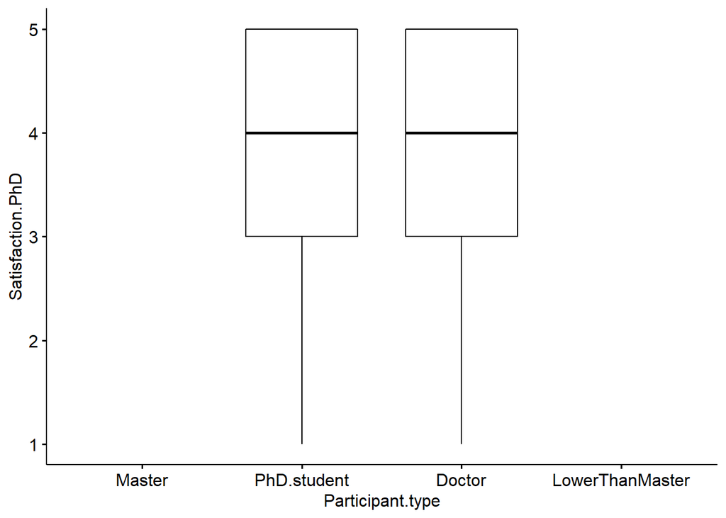

… pretty similar distribution for doctors and PhD students.

### Frequency of experience

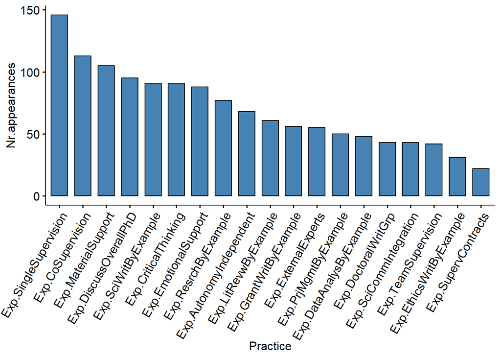

### Usefulness

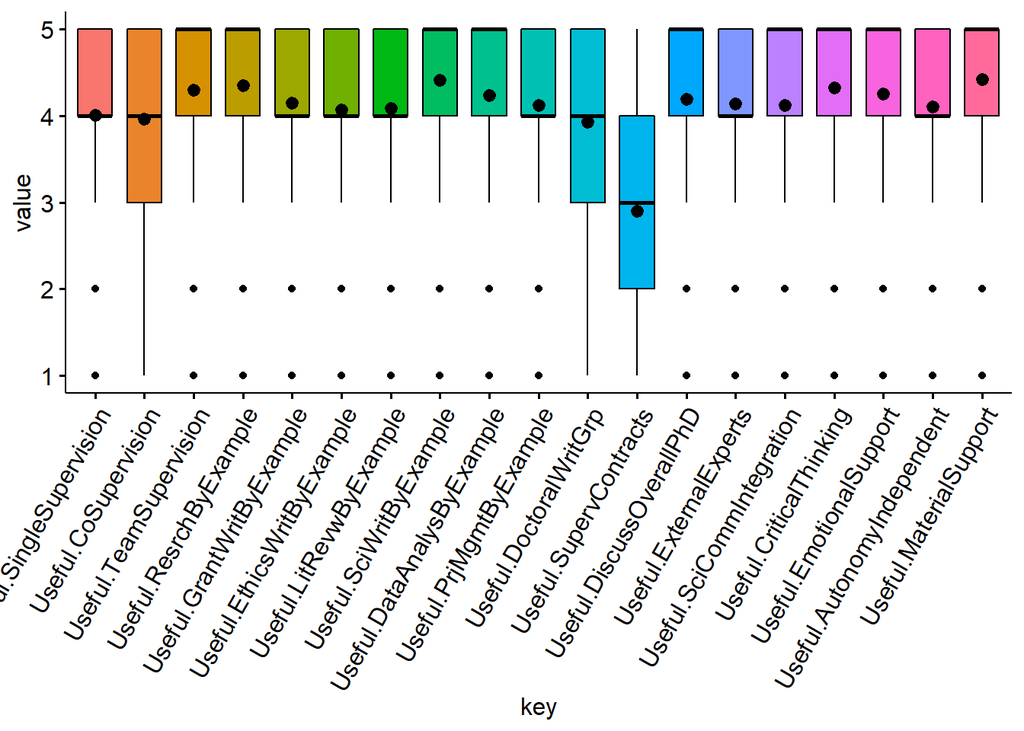

### Scatter of Usefulness vs. frequency

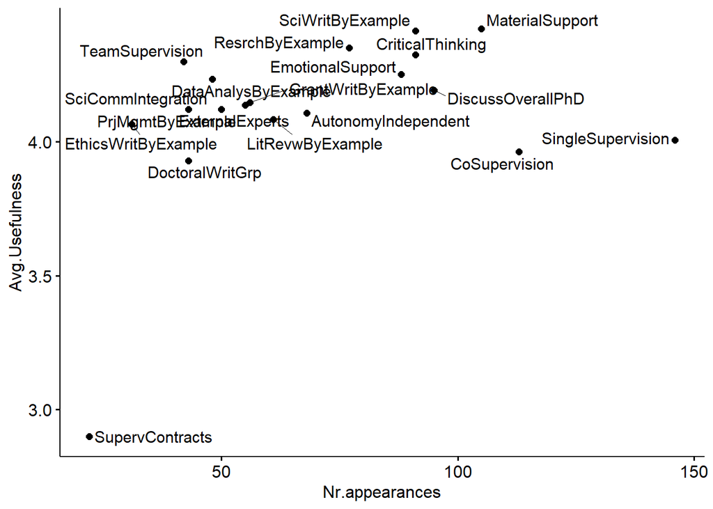

So, we may want to emphasize the practice on the top-left (or those in the top, generally)… Team supervision, Research or writing or data analysis by example, emotional support.

### PCA/MDS of usefulness

TODO: are there things that are considered useful together?

Maybe not that interesting

### PCA/MDS of frequency

TODO: are there things that appear/are experienced together?

Maybe not that interesting

### Distribution of satisfaction with supervision per experienced practice

How satisfied with the PhD are people that have experienced/not experienced different practices?

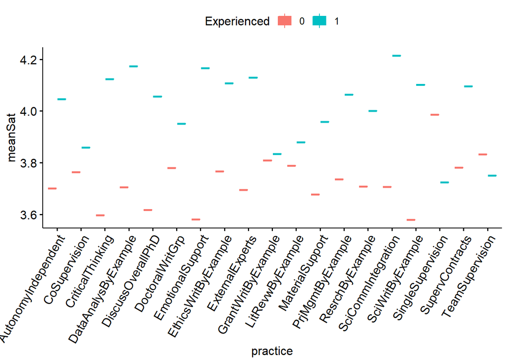

| Experienced | meanSat | practice |
| --- | --- | --- |
| 0 | 4.0 | SingleSupervision |
| 1 | 3.7 | SingleSupervision |
| 0 | 3.8 | CoSupervision |
| 1 | 3.9 | CoSupervision |
| 0 | 3.8 | TeamSupervision |
| 1 | 3.8 | TeamSupervision |
| 0 | 3.7 | ResrchByExample |
| 1 | 4.0 | ResrchByExample |
| 0 | 3.8 | GrantWritByExample |
| 1 | 3.8 | GrantWritByExample |
| 0 | 3.8 | EthicsWritByExample |
| 1 | 4.1 | EthicsWritByExample |
| 0 | 3.8 | LitRevwByExample |
| 1 | 3.9 | LitRevwByExample |
| 0 | 3.6 | SciWritByExample |
| 1 | 4.1 | SciWritByExample |
| 0 | 3.7 | DataAnalysByExample |
| 1 | 4.2 | DataAnalysByExample |
| 0 | 3.7 | PrjMgmtByExample |
| 1 | 4.1 | PrjMgmtByExample |
| 0 | 3.8 | DoctoralWritGrp |
| 1 | 4.0 | DoctoralWritGrp |
| 0 | 3.8 | SupervContracts |
| 1 | 4.1 | SupervContracts |
| 0 | 3.6 | DiscussOverallPhD |
| 1 | 4.1 | DiscussOverallPhD |
| 0 | 3.7 | ExternalExperts |
| 1 | 4.1 | ExternalExperts |
| 0 | 3.7 | SciCommIntegration |
| 1 | 4.2 | SciCommIntegration |
| 0 | 3.6 | CriticalThinking |
| 1 | 4.1 | CriticalThinking |
| 0 | 3.6 | EmotionalSupport |
| 1 | 4.2 | EmotionalSupport |
| 0 | 3.7 | AutonomyIndependent |
| 1 | 4.0 | AutonomyIndependent |
| 0 | 3.7 | MaterialSupport |
| 1 | 4.0 | MaterialSupport |

So it seems that experiencing certain practices is related to higher satisfaction (most of them, with ScientificWritingByExample, DataAnalysisbyExample, DiscussOverallPhD, SciCommIntegration, CriticalThinking, EmotionalSupport being the most dramatic differences), while others seem to make no difference (TeamSupervision, GrantWritingbyExample), and others lead to LOWER satisfaction (SingleSupervision).

Barplots with errorbars…

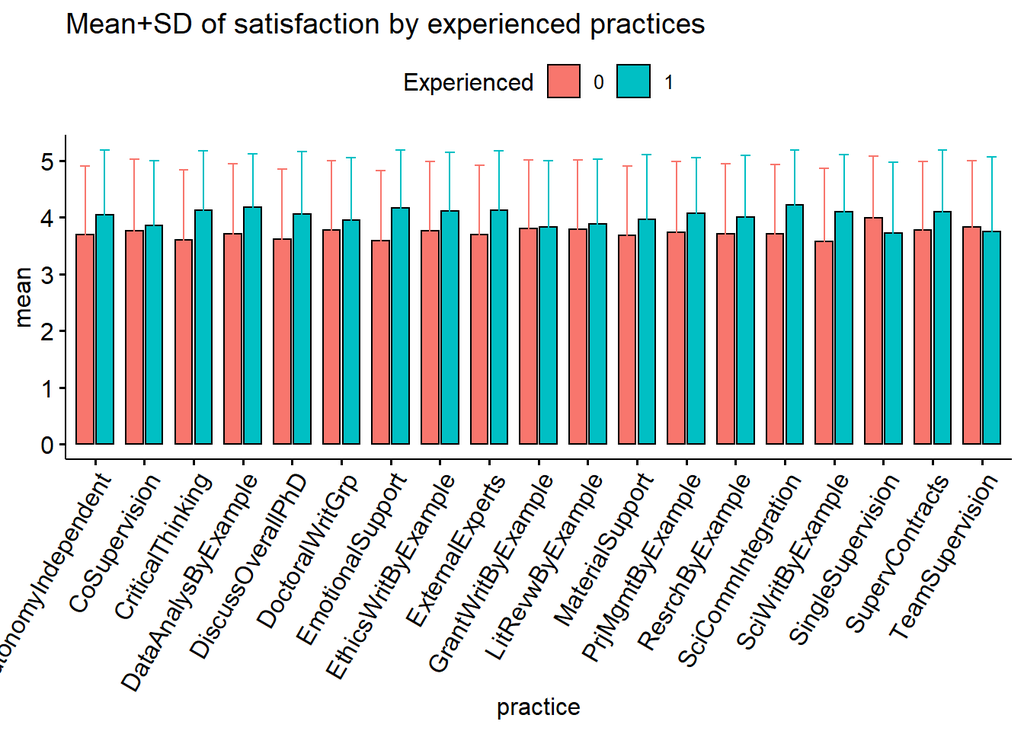

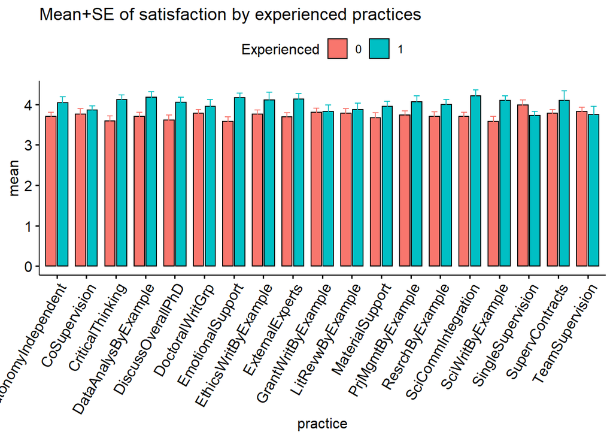

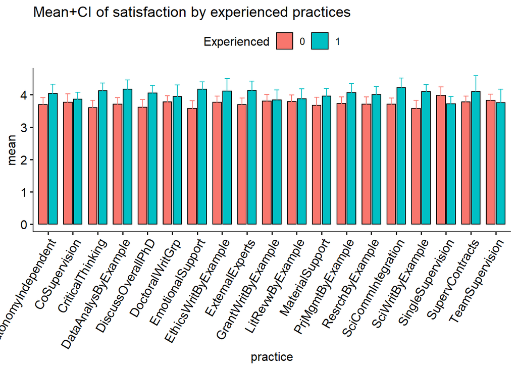

Are there differences by whether people are doctors or not, in this satisfaction with PhD?

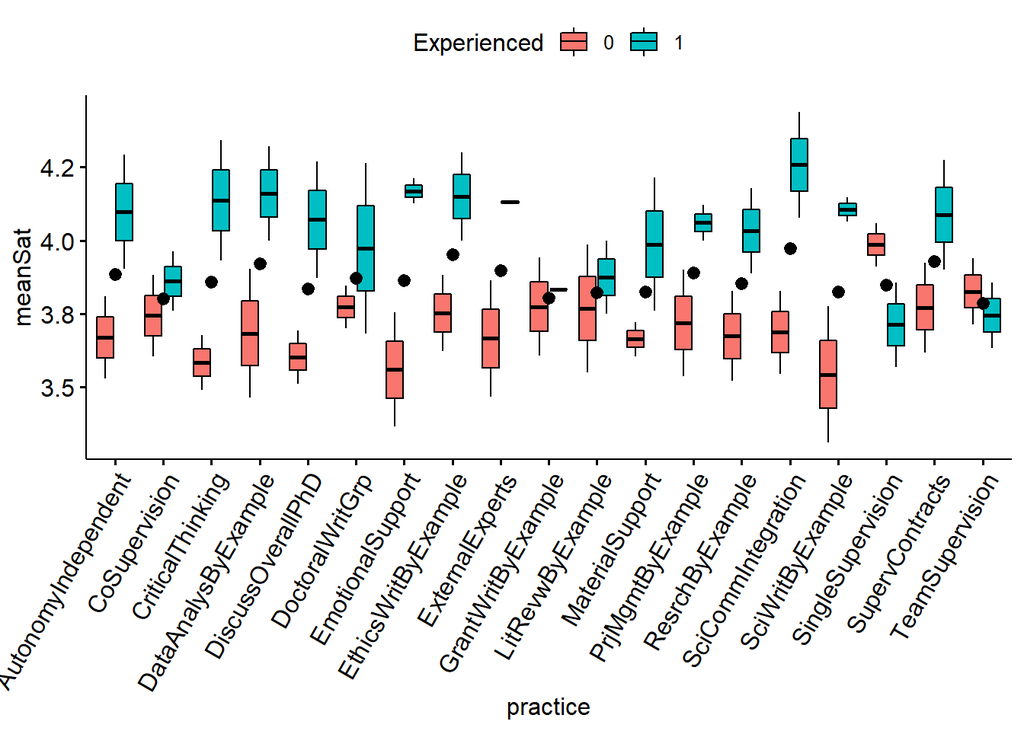

| Participant.type | Experienced | meanSat | practice |
| --- | --- | --- | --- |
| PhD.student | 0 | 4.1 | SingleSupervision |
| PhD.student | 1 | 3.9 | SingleSupervision |
| Doctor | 0 | 3.9 | SingleSupervision |
| Doctor | 1 | 3.6 | SingleSupervision |
| PhD.student | 0 | 3.9 | CoSupervision |
| PhD.student | 1 | 4.0 | CoSupervision |
| Doctor | 0 | 3.6 | CoSupervision |
| Doctor | 1 | 3.8 | CoSupervision |
| PhD.student | 0 | 3.9 | TeamSupervision |
| PhD.student | 1 | 3.9 | TeamSupervision |
| Doctor | 0 | 3.7 | TeamSupervision |
| Doctor | 1 | 3.6 | TeamSupervision |
| PhD.student | 0 | 3.8 | ResrchByExample |
| PhD.student | 1 | 4.2 | ResrchByExample |
| Doctor | 0 | 3.5 | ResrchByExample |
| Doctor | 1 | 3.9 | ResrchByExample |
| PhD.student | 0 | 3.9 | GrantWritByExample |
| PhD.student | 1 | 3.8 | GrantWritByExample |
| Doctor | 0 | 3.6 | GrantWritByExample |
| Doctor | 1 | 3.8 | GrantWritByExample |
| PhD.student | 0 | 3.9 | EthicsWritByExample |
| PhD.student | 1 | 4.3 | EthicsWritByExample |
| Doctor | 0 | 3.6 | EthicsWritByExample |
| Doctor | 1 | 4.0 | EthicsWritByExample |
| PhD.student | 0 | 4.0 | LitRevwByExample |
| PhD.student | 1 | 3.8 | LitRevwByExample |
| Doctor | 0 | 3.5 | LitRevwByExample |
| Doctor | 1 | 4.0 | LitRevwByExample |
| PhD.student | 0 | 3.8 | SciWritByExample |
| PhD.student | 1 | 4.2 | SciWritByExample |
| Doctor | 0 | 3.3 | SciWritByExample |
| Doctor | 1 | 4.1 | SciWritByExample |
| PhD.student | 0 | 3.9 | DataAnalysByExample |
| PhD.student | 1 | 4.0 | DataAnalysByExample |
| Doctor | 0 | 3.5 | DataAnalysByExample |
| Doctor | 1 | 4.3 | DataAnalysByExample |
| PhD.student | 0 | 3.9 | PrjMgmtByExample |
| PhD.student | 1 | 4.0 | PrjMgmtByExample |
| Doctor | 0 | 3.5 | PrjMgmtByExample |
| Doctor | 1 | 4.1 | PrjMgmtByExample |
| PhD.student | 0 | 3.8 | DoctoralWritGrp |
| PhD.student | 1 | 4.3 | DoctoralWritGrp |
| Doctor | 0 | 3.7 | DoctoralWritGrp |
| Doctor | 1 | 3.7 | DoctoralWritGrp |
| PhD.student | 0 | 3.9 | SupervContracts |
| PhD.student | 1 | 3.9 | SupervContracts |
| Doctor | 0 | 3.6 | SupervContracts |
| Doctor | 1 | 4.3 | SupervContracts |
| PhD.student | 0 | 3.7 | DiscussOverallPhD |
| PhD.student | 1 | 4.3 | DiscussOverallPhD |
| Doctor | 0 | 3.5 | DiscussOverallPhD |
| Doctor | 1 | 3.9 | DiscussOverallPhD |
| PhD.student | 0 | 3.9 | ExternalExperts |
| PhD.student | 1 | 4.1 | ExternalExperts |
| Doctor | 0 | 3.5 | ExternalExperts |
| Doctor | 1 | 4.1 | ExternalExperts |
| PhD.student | 0 | 3.8 | SciCommIntegration |
| PhD.student | 1 | 4.4 | SciCommIntegration |
| Doctor | 0 | 3.5 | SciCommIntegration |
| Doctor | 1 | 4.1 | SciCommIntegration |
| PhD.student | 0 | 3.7 | CriticalThinking |
| PhD.student | 1 | 4.3 | CriticalThinking |
| Doctor | 0 | 3.5 | CriticalThinking |
| Doctor | 1 | 3.9 | CriticalThinking |
| PhD.student | 0 | 3.8 | EmotionalSupport |
| PhD.student | 1 | 4.2 | EmotionalSupport |
| Doctor | 0 | 3.4 | EmotionalSupport |
| Doctor | 1 | 4.1 | EmotionalSupport |
| PhD.student | 0 | 3.8 | AutonomyIndependent |
| PhD.student | 1 | 4.3 | AutonomyIndependent |
| Doctor | 0 | 3.5 | AutonomyIndependent |
| Doctor | 1 | 3.9 | AutonomyIndependent |
| PhD.student | 0 | 3.7 | MaterialSupport |
| PhD.student | 1 | 4.2 | MaterialSupport |
| Doctor | 0 | 3.6 | MaterialSupport |
| Doctor | 1 | 3.8 | MaterialSupport |

Seems that the trends are similar, only that Doctors tend to be less satisfied on average…

### Usefulness/satisfaction and demographics

TODO: maybe not so interesting?

### Partial correlation/GGM of challenges and supervision practice appearance/usefulness

Relations between challenges and satisfaction with PhD and demographics

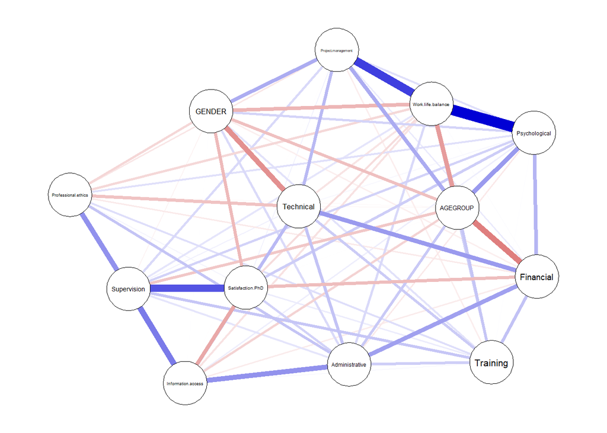

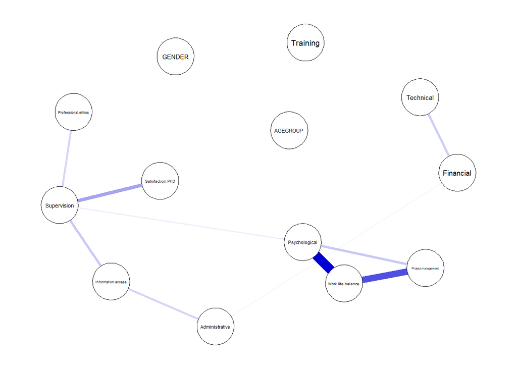

It seems that supervision challenges are most related to satisfaction, once we control by the other challenges.

What about the relationship of experienced practices vs. satisfaction and supervision challenges?

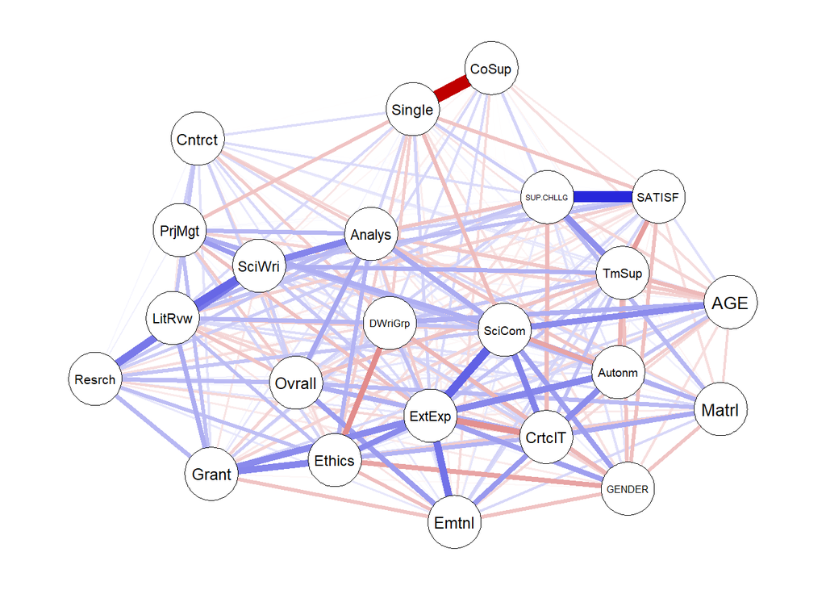

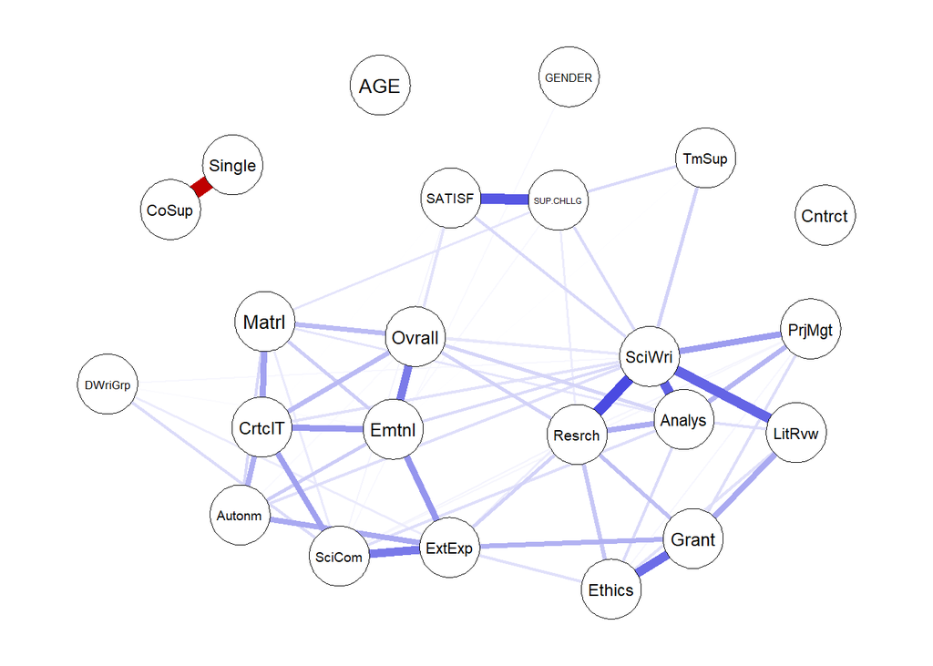

### Linear regression of supervision challenge or satisfaction with apperance or usefulness of practices

Regression of satisfaction

```
##
## Call:
## lm(formula = SATISF ~ TmSup + SciWri + CrtclT + Emtnl, data = datalm)
##
## Residuals:
##    Min     1Q Median     3Q    Max
## -3.200 -0.528  0.172  0.800  1.917
##
## Coefficients:
##             Estimate Std. Error t value Pr(>|t|)
## (Intercept)    3.411      0.129   26.46   <2e-16 ***
## TmSup         -0.328      0.210   -1.56    0.119
## SciWri         0.425      0.178    2.38    0.018 *
## CrtclT         0.321      0.183    1.76    0.080 .
## Emtnl          0.371      0.185    2.00    0.047 *
## ---
## Signif. codes:  0 '***' 0.001 '**' 0.01 '*' 0.05 '.' 0.1 ' ' 1
##
## Residual standard error: 1.1 on 186 degrees of freedom
## Multiple R-squared:  0.109,  Adjusted R-squared:  0.0895
## F-statistic: 5.67 on 4 and 186 DF,  p-value: 0.000251
```

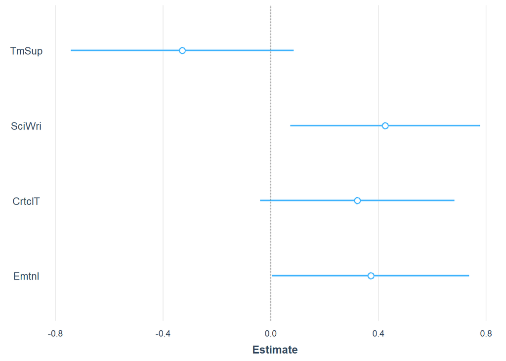

Regression of finding supervision aspects (not) challenging (higher is)

```
##
## Call:
## lm(formula = SUP.CHLLG ~ TmSup + SciWri + Cntrct + Matrl, data = datalm)
##
## Residuals:
##    Min     1Q Median     3Q    Max
## -2.600 -0.803  0.197  0.923  2.197
##
## Coefficients:
##             Estimate Std. Error t value Pr(>|t|)
## (Intercept)    2.803      0.139   20.15   <2e-16 ***
## TmSup          0.478      0.219    2.18    0.031 *
## SciWri         0.418      0.187    2.24    0.026 *
## Cntrct         0.414      0.281    1.47    0.142
## Matrl          0.378      0.181    2.10    0.037 *
## ---
## Signif. codes:  0 '***' 0.001 '**' 0.01 '*' 0.05 '.' 0.1 ' ' 1
##
## Residual standard error: 1.2 on 176 degrees of freedom
## Multiple R-squared:  0.125,  Adjusted R-squared:  0.105
## F-statistic: 6.28 on 4 and 176 DF,  p-value: 9.61e-05
```

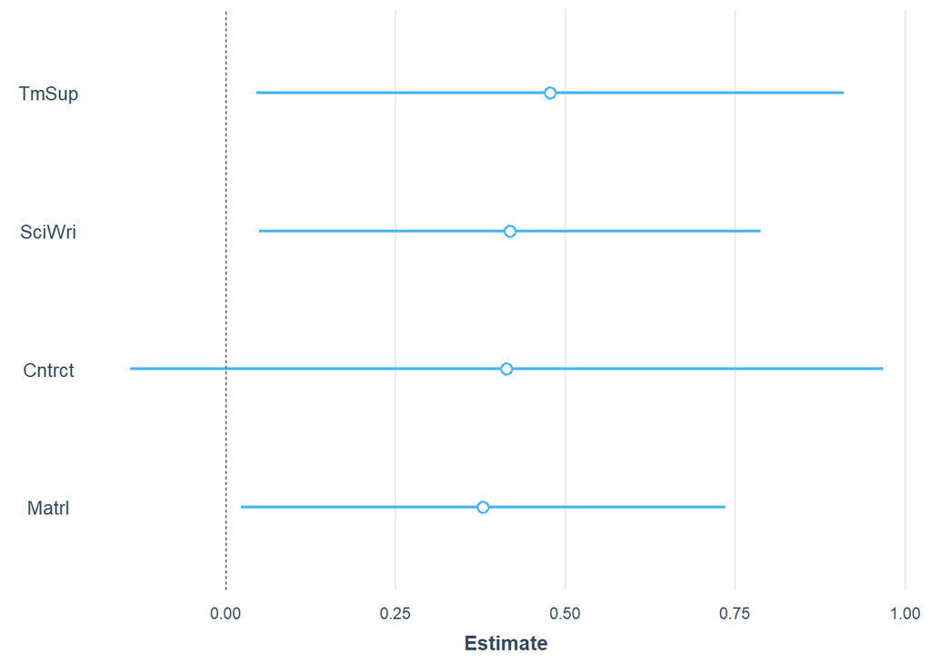

We try both at the same time with GGM, using only the predictors that came up in the parsimonious models

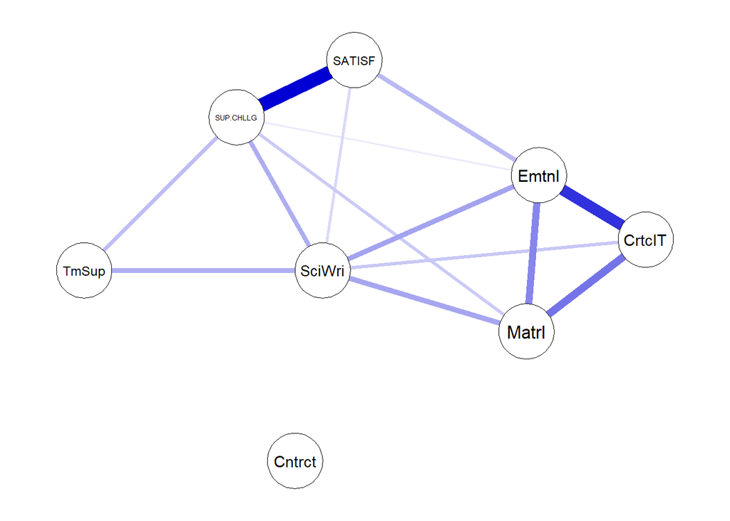

Or, more simply, trying to get at connections between practices and satisfaction:

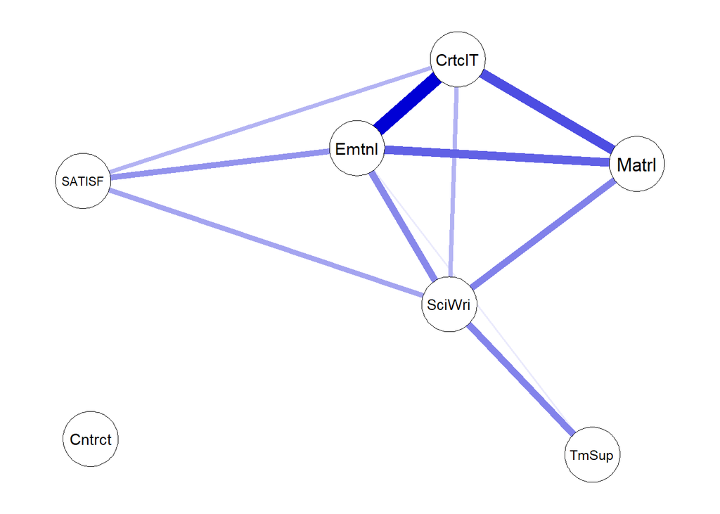

We see support to critical thinking, scientific writing by example and emotional support as most directly related to satisfaction, with team supervision and material support more indirectly related to it. Scientific writing support seems the most central concept in the network.